# Today we're going to learn about

- Replication and reproducibility and http://git-scm.com and http://github.com
- Python (and IPython)
- Numerical computing in Python using `numpy`
- Plotting in Python using `matplotlib`

# But first ...

You need to have a distribution of Python installed, with all the modules we're going to use in this course.

The best way to ensure that is by installing the **Anaconda Scientific Python Distribution**:

- Go to http://continuum.io/downloads and follow the instructions for your platform

Once you're done:

```
$ python -V
Python 2.7.9 :: Anaconda 2.1.0 (x86_64)
```

# Note

Lots of content to go through today. If we don't make it all the way, see the rest of this presentation at:

- http://goo.gl/JR0pD8 (IPython notebook)
- http://goo.gl/vVMvlp (rendered slides)

You'll also be able to review it on YouTube (link will be posted after class)

# git, github, etc... Why do we care?

**Replication** and **reproducibility** are two of the cornerstones in the scientific method. With respect to data analysis (and scientific computing in general!), these concepts have the following practical implications:

- **Replication**: An author of a scientific paper that involves some data analysis should be able to rerun the analysis code and replicate the results upon request. Other scientists should be able to perform the same analysis and obtain the same results, given the information about the methods used in a publication.
- **Reproducibility**: The results obtained by analyzing the data should be reproducible with an independent implementation of the method, or using a different method altogether.

In summary: A sound scientific result should be reproducible, and a sound scientific study should be replicable.

To achieve these goals, we need to:

- Keep and take note of *exactly* which source code and version that was used to produce data and figures in published papers.
- Record information of which version of external software that was used. Keep access to the environment that was used.
- Make sure that old codes and notes are backed up and kept for future reference.
- Ideally codes should be published online, to make it easier for other scientists interested in the codes to access it.

Ensuring replicability and reproducibility of data analyses is a *difficult and complex problem*. In general, full end-to-end reproducibility is very difficult to attain.

However, there are tools that can help get us very close:

- Version Control System systems (VCSs):
  - Good choices include:
    - **git - http://git-scm.com**
    - mercurial - http://mercurial.selenic.com. Also known as `hg`.
    - *DO NOT USE: rcs, cvs, svn, perforce, ... Considered harmful!*
- Online repositories for source code. Available as both private and public repositories.
  - Some good alternatives are
    - **GitHub - http://www.github.com**
    - Bitbucket - http://www.bitbucket.com
    - Privately hosted repositories on the university's or department's servers.

# git+github: introduction by example

- Tracking changes in your content
- Organizing changes: branching and merging
- Sharing changes: github repositories, pushing and pulling
- Contributing to others: pull requests, code reviews

# GitHub Student Developer Pack

https://education.github.com/pack

[figure not shown]

#### Note

Repositories are also excellent for version controlling manuscripts, figures, thesis files, data files, lab logs, etc. Basically for any digital content that must be preserved and is frequently updated.

Both public and private repositories are readily available.

They are also excellent collaboration tools!

### Finding out more

- [Google](http://google.com)
- [YouTube](http://youtube.com)
- [Scott Chacon on git](https://www.youtube.com/watch?v=ZDR433b0HJY)
- [gitref.org](http://gitref.org/index.html)
- [LSST's page on git](https://confluence.lsstcorp.org/display/LDMDG/Using+Git+for+LSST+Development)
- [git website](http://git-scm.com)
- github.com
- [Reproducible Research in Computational Science](http://dx.doi.org/10.1126/science.1213847), Roger D. Peng, Science 334, 1226 (2011).
- [Shining Light into Black Boxes](http://dx.doi.org/10.1126/science.1218263), A. Morin et al., Science 336, 159-160 (2012).
- [The case for open computer programs](http://dx.doi.org/doi:10.1038/nature10836), D.C. Ince, Nature 482, 485 (2012).

# A Short Introduction to Python

Based on the notebooks by J.R. Johansson (robert@riken.jp) from http://github.com/jrjohansson/scientific-python-lectures.

## Note

I think most of you are familiar with basic Python (or can at least read it). Here, I'll largely concentrate on numerical (`numpy`) and plotting libraries (`matplotlib`). More topics (e.g., more advanced data analysis packages, databases, visualization) will be covered later in ASTR 597b.

If you don't have much experience with Python, there are a number of online resources/tutorials:

- [Software Carpentry Python Tutorials](http://software-carpentry.org/v4/python/)
- [A Crash Course in Python for Scientists, by Rick Muller](http://nbviewer.ipython.org/gist/rpmuller/5920182)
- [Scientific Python Lecture Notes](http://scipy-lectures.github.io)

as well as some excellent books:

- [Learning Python, by Mark Lutz](http://www.amazon.com/Learning-Python-Edition-Mark-Lutz/dp/1449355730)

## What is Python?

[Python](http://www.python.org/) is a modern, general-purpose, object-oriented, high-level programming language.

General characteristics of Python:

- **clean and simple language:** Easy-to-read and intuitive code, easy-to-learn minimalistic syntax, maintainability scales well with size of projects.
- **expressive language:** Fewer lines of code, fewer bugs, easier to maintain.

Technical details:

- **dynamically typed:** No need to define the type of variables, function arguments or return types.
- **automatic memory management:** No need to explicitly allocate and deallocate memory for variables and data arrays. No memory leak bugs.
- **interpreted:** No need to compile the code. The Python interpreter reads and executes the python code directly.

### Advantages:

- The main advantage is ease of programming, minimizing the time required to develop, debug and maintain the code.
- Well designed language that encourage many good programming practices:
- Modular and object-oriented programming, good system for packaging and re-use of code. This often results in more transparent, maintainable and bug-free code.
- Documentation tightly integrated with the code.
- A large standard library, and a large collection of add-on packages.

### Disadvantages:

- Since Python is an interpreted and dynamically typed programming language, the execution of python code can be slow compared to compiled statically typed programming languages, such as C and Fortran.
- Somewhat decentralized, with different environment, packages and documentation spread out at different places. Can make it harder to get started.

# What makes Python suitable for scientific computing?

[figure not shown]

- Python has a strong position in scientific computing:
  - Large community of users, easy to find help and documentation.
- Extensive ecosystem of scientific libraries and environments
  - numpy: http://numpy.scipy.org - Numerical Python
  - scipy: http://www.scipy.org - Scientific Python
  - matplotlib: http://www.matplotlib.org - graphics library
- Great performance due to close integration with time-tested and highly optimized codes written in C and Fortran:
  - blas, altas blas, lapack, arpack, Intel MKL, ...
- Readily available and suitable for use on high-performance computing clusters.
- No license costs, no unnecessary use of research budget.

## Python interpreter

The standard way to use the Python programming language is to use the Python interpreter to run python code. The python interpreter is a program that read and execute the python code in files passed to it as arguments. At the command prompt, the command `python` is used to invoke the Python interpreter.

For example, to run a file `my-program.py` that contains python code from the command prompt, use:

```
$ python my-program.py
```

## Python programs

- Python code is usually stored in text files with the file ending "`.py`":

  ```
  myprogram.py
  ```

- Every line in a Python program file is assumed to be a Python statement, or part thereof.
  - The only exception is comment lines, which start with the character `#` (optionally preceded by an arbitrary number of white-space characters, i.e., tabs or spaces). Comment lines are usually ignored by the Python interpreter.
- To run our Python program from the command line we use:

  ```
  $ python myprogram.py
  ```

- On UNIX systems it is common to define the path to the interpreter on the first line of the program (note that this is a comment line as far as the Python interpreter is concerned):

  ```
  #!/usr/bin/env python
  ```

If we do, and if we additionally set the file script to be executable, we can run the program like this:

```
    $ myprogram.py
```

We can also start the interpreter by simply typing `python` at the command line, and interactively type python code into the interpreter.

[figure not shown]

This is often how we want to work when developing scientific applications, or when doing small calculations. But the standard python interpreter is not very convenient for this kind of work, due to a number of limitations.

### IPython

IPython is an interactive shell that addresses the limitation of the standard python interpreter, and it is a work-horse for scientific use of python. It provides an interactive prompt to the python interpreter with a greatly improved user-friendliness.

[figure not shown]

### Some of the many useful features of IPython include:

- Command history, which can be browsed with the up and down arrows on the keyboard.
- Tab auto-completion.
- In-line editing of code.
- Object introspection, and automatic extract of documentation strings from python objects like classes and functions.
- Good interaction with operating system shell.
- Support for multiple parallel back-end processes, that can run on computing clusters or cloud services like Amazon EE2.

### IPython notebook

[IPython notebook](http://ipython.org/notebook.html) is an HTML-based notebook environment for Python, similar to Mathematica or Maple. It is based on the IPython shell, but provides a cell-based environment with great interactivity, where calculations can be organized documented in a structured way.

[figure not shown]

Although using the a web browser as graphical interface, IPython notebooks are usually run locally, from the same computer that run the browser. To start a new IPython notebook session, run the following command:

```
$ ipython notebook
```

from a directory where you want the notebooks to be stored. This will open a new browser window (or a new tab in an existing window) with an index page where existing notebooks are shown and from which new notebooks can be created.

### Spyder

[Spyder](http://code.google.com/p/spyderlib/) is a MATLAB-like IDE for scientific computing with python. It has the many advantages of a traditional IDE environment, for example that everything from code editing, execution and debugging is carried out in a single environment, and work on different calculations can be organized as projects in the IDE environment.

[figure not shown]

Some advantages of Spyder:

- Powerful code editor, with syntax high-lighting, dynamic code introspection and integration with the python debugger.
- Variable explorer, IPython command prompt.
- Integrated documentation and help.

## Versions of Python

There are currently two versions of python: Python 2 and Python 3. Python 3 will eventually supersede Python 2, but it is not backward-compatible with Python 2. A lot of existing python code and packages has been written for Python 2, and it is still the most wide-spread version. For these lectures either version will be fine, but it is probably easier to stick with Python 2 for now, because it is more readily available via pre-built packages and binary installers.

To see which version of Python you have, run

```
$ python --version
Python 2.7.3
$ python3.2 --version
Python 3.2.3
```

Several versions of Python can be installed in parallel, as shown above.

# Numpy - multidimensional data arrays

## Why `numpy`?

Performance and ease of use.

The `numpy` package (module) is used in almost all numerical computation using Python. It is a package that provide high-performance vector, matrix and higher-dimensional data structures for Python. It is implemented in C and Fortran so when calculations are vectorized (formulated with vectors and matrices), performance is very good.

To use `numpy` need to import the module it using of example:

```python
import numpy as np
```

In the `numpy` package the terminology used for vectors, matrices and higher-dimensional data sets is *array*.

## Creating `numpy` arrays

There are a number of ways to initialize new numpy arrays, for example from

- a Python list or tuples
- using functions that are dedicated to generating numpy arrays, such as `arange`, `linspace`, etc.
- reading data from files

### From lists

For example, to create new vector and matrix arrays from Python lists we can use the `numpy.array` function.

```python
# a vector: the argument to the array function is a Python list
v = np.array([1,2,3,4])

v
```

```
array([1, 2, 3, 4])
```

```python
# a matrix: the argument to the array function is a nested Python list
M = np.array([[1, 2], [3, 4]])

M
```

```
array([[1, 2],
       [3, 4]])
```

The `v` and `M` objects are both of the type `ndarray` that the `numpy` module provides.

```python
type(v), type(M)
```

```
(numpy.ndarray, numpy.ndarray)
```

The difference between the `v` and `M` arrays is only their shapes. We can get information about the shape of an array by using the `ndarray.shape` property.

```python
v.shape
```

```
(4,)
```

```python
M.shape
```

```
(2, 2)
```

The number of elements in the array is available through the `ndarray.size` property:

```python
M.size
```

```
4
```

So far the `numpy.ndarray` looks awfully much like a Python list (or nested list). Why not simply use Python lists for computations instead of creating a new array type?

There are several reasons:

- Python lists are very general. They can contain any kind of object. They are dynamically typed. They do not support mathematical functions such as matrix and dot multiplications, etc. Implementing such functions for Python lists would not be very efficient because of the dynamic typing.
- Numpy arrays are **statically typed** and **homogeneous**. The type of the elements is determined when array is created.
- Numpy arrays are memory efficient.
- Because of the static typing, fast implementation of mathematical functions such as multiplication and addition of `numpy` arrays can be implemented in a compiled language (C and Fortran is used).

Using the `dtype` (data type) property of an `ndarray`, we can see what type the data of an array has:

```python
M.dtype
```

```
dtype('int64')
```

We get an error if we try to assign a value of the wrong type to an element in a numpy array:

```python
M[0,0] = "hello"
```

```
---------------------------------------------------------------------------
ValueError                                Traceback (most recent call last)
<ipython-input-10-a09d72434238> in <module>()
----> 1 M[0,0] = "hello"

ValueError: invalid literal for long() with base 10: 'hello'
```

If we want, we can explicitly define the type of the array data when we create it, using the `dtype` keyword argument:

```python
M = np.array([[1, 2], [3, 4]], dtype=float)

M
```

```
array([[ 1.,  2.],
       [ 3.,  4.]])
```

Common type that can be used with `dtype` are: `int`, `float`, `complex`, `bool`, `object`, etc.

We can also explicitly define the bit size of the data types, for example: `int64`, `int16`, `float128`, `complex128`.

### Using array-generating functions

For larger arrays it is impractical to initialize the data manually, using explicit python lists. Instead we can use one of the many functions in `numpy` that generates arrays of different forms. Some of the more common are:

#### arange

```python
# create a range

x = np.arange(0, 10, 1) # arguments: start, stop, step

x
```

```
array([0, 1, 2, 3, 4, 5, 6, 7, 8, 9])
```

#### linspace and logspace

```python
# using linspace, both end points ARE included
np.linspace(0, 10, 25)
```

```
array([  0.        ,   0.41666667,   0.83333333,   1.25      ,
         1.66666667,   2.08333333,   2.5       ,   2.91666667,
         3.33333333,   3.75      ,   4.16666667,   4.58333333,
         5.        ,   5.41666667,   5.83333333,   6.25      ,
         6.66666667,   7.08333333,   7.5       ,   7.91666667,
         8.33333333,   8.75      ,   9.16666667,   9.58333333,  10.        ])
```

```python
np.logspace(0, 10, 10, base=e)
```

```
array([  1.00000000e+00,   3.03773178e+00,   9.22781435e+00,
         2.80316249e+01,   8.51525577e+01,   2.58670631e+02,
         7.85771994e+02,   2.38696456e+03,   7.25095809e+03,
         2.20264658e+04])
```

#### zeros and ones

```python
np.zeros((3,3))
```

```
array([[ 0.,  0.,  0.],
       [ 0.,  0.,  0.],
       [ 0.,  0.,  0.]])
```

```python
np.ones((3,3))
```

```
array([[ 1.,  1.,  1.],
       [ 1.,  1.,  1.],
       [ 1.,  1.,  1.]])
```

## Reading Data from Files

### Comma-separated values (CSV)

A very common file format for data files are the comma-separated values (CSV), or related format such as TSV (tab-separated values). To read data from such file into Numpy arrays we can use the `numpy.genfromtxt` function. For example,

```python
!head td_adj.dat
```

```
1800  1  1    -6.1    -6.1    -6.1 1
1800  1  2   -15.4   -15.4   -15.4 1
1800  1  3   -15.0   -15.0   -15.0 1
1800  1  4   -19.3   -19.3   -19.3 1
1800  1  5   -16.8   -16.8   -16.8 1
1800  1  6   -11.4   -11.4   -11.4 1
1800  1  7    -7.6    -7.6    -7.6 1
1800  1  8    -7.1    -7.1    -7.1 1
1800  1  9   -10.1   -10.1   -10.1 1
1800  1 10    -9.5    -9.5    -9.5 1
```

```python
data = np.genfromtxt('td_adj.dat')
```

```python
data.shape
```

```
(77431, 7)
```

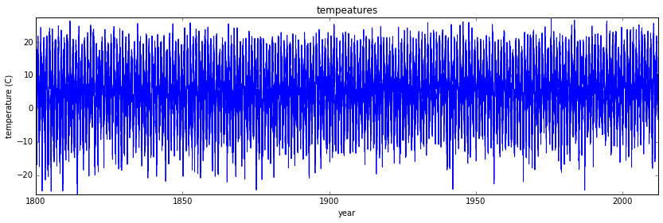

```python
fig, ax = subplots(figsize=(14,4))
ax.plot(data[:,0]+data[:,1]/12.0+data[:,2]/365, data[:,5])
ax.axis('tight')
ax.set_title('tempeatures')
ax.set_xlabel('year')
ax.set_ylabel('temperature (C)');
```

Using `numpy.savetxt` we can store a Numpy array to a file in CSV format:

```python
M = np.random.rand(3,3)

M
```

```
array([[ 0.41265096,  0.61924523,  0.58195791],
       [ 0.84519384,  0.58952953,  0.93024832],
       [ 0.52730389,  0.68092862,  0.0186186 ]])
```

```python
np.savetxt("random-matrix.csv", M)
```

```python
!cat random-matrix.csv
```

```
4.126509580363927343e-01 6.192452313973364486e-01 5.819579109567533104e-01
8.451938428951624172e-01 5.895295296232047066e-01 9.302483228022416784e-01
5.273038901613262830e-01 6.809286175446855882e-01 1.861859571669244318e-02
```

```python
np.savetxt("random-matrix.csv", M, fmt='%.5f') # fmt specifies the format

!cat random-matrix.csv
```

```
0.41265 0.61925 0.58196
0.84519 0.58953 0.93025
0.52730 0.68093 0.01862
```

# Reading formats common in astronomy

The most frequently used format is FITS. A very capable FITS reader and writer exists as a part of the [astropy](http://astropy.org) package.

Another common format is HDF5. See the [pytables](http://pytables.org) package for reading and writing HDF.

## Manipulating arrays

### Indexing

We can index elements in an array using the square bracket and indices:

```python
# v is a vector, and has only one dimension, taking one index
v[0]
```

```
1
```

```python
# M is a matrix, or a 2 dimensional array, taking two indices
M[1,1]
```

```
0.58952952962320471
```

If we omit an index of a multidimensional array it returns the whole row (or, in general, a N-1 dimensional array)

```python
M
```

```
array([[ 0.41265096,  0.61924523,  0.58195791],
       [ 0.84519384,  0.58952953,  0.93024832],
       [ 0.52730389,  0.68092862,  0.0186186 ]])
```

```python
M[1]
```

```
array([ 0.84519384,  0.58952953,  0.93024832])
```

The same thing can be achieved with using `:` instead of an index:

```python
M[1,:] # row 1
```

```
array([ 0.84519384,  0.58952953,  0.93024832])
```

```python
M[:,1] # column 1
```

```
array([ 0.61924523,  0.58952953,  0.68092862])
```

We can assign new values to elements in an array using indexing:

```python
M[0,0] = 1
```

```python
M
```

```
array([[ 1.        ,  0.61924523,  0.58195791],
       [ 0.84519384,  0.58952953,  0.93024832],
       [ 0.52730389,  0.68092862,  0.0186186 ]])
```

```python
# also works for rows and columns
M[1,:] = 0
M[:,2] = -1
```

```python
M
```

```
array([[ 1.        ,  0.61924523, -1.        ],
       [ 0.        ,  0.        , -1.        ],
       [ 0.52730389,  0.68092862, -1.        ]])
```

### Index slicing

Index slicing is the technical name for the syntax `M[lower:upper:step]` to extract part of an array:

```python
A = array([1,2,3,4,5])
A
```

```
array([1, 2, 3, 4, 5])
```

```python
A[1:3]
```

```
array([2, 3])
```

Array slices are *mutable*: if they are assigned a new value the original array from which the slice was extracted is modified:

```python
A[1:3] = [-2,-3]

A
```

```
array([ 1, -2, -3,  4,  5])
```

We can omit any of the three parameters in `M[lower:upper:step]`:

```python
A[::] # lower, upper, step all take the default values
```

```
array([ 1, -2, -3,  4,  5])
```

```python
A[::2] # step is 2, lower and upper defaults to the beginning and end of the array
```

```
array([ 1, -3,  5])
```

```python
A[:3] # first three elements
```

```
array([ 1, -2, -3])
```

```python
A[3:] # elements from index 3
```

```
array([4, 5])
```

Negative indices counts from the end of the array (positive index from the beginning):

```python
A = array([1,2,3,4,5])
```

```python
A[-1] # the last element in the array
```

```
5
```

```python
A[-3:] # the last three elements
```

```
array([3, 4, 5])
```

Index slicing works exactly the same way for multidimensional arrays:

```python
A = array([[n+m*10 for n in range(5)] for m in range(5)])

A
```

```
array([[ 0,  1,  2,  3,  4],
       [10, 11, 12, 13, 14],
       [20, 21, 22, 23, 24],
       [30, 31, 32, 33, 34],
       [40, 41, 42, 43, 44]])
```

```python
# a block from the original array
A[1:4, 1:4]
```

```
array([[11, 12, 13],
       [21, 22, 23],
       [31, 32, 33]])
```

```python
# strides
A[::2, ::2]
```

```
array([[ 0,  2,  4],
       [20, 22, 24],
       [40, 42, 44]])
```

### Fancy indexing

Fancy indexing is the name for when an array or list is used in-place of an index:

```python
row_indices = [1, 2, 3]
A[row_indices]
```

```
array([[10, 11, 12, 13, 14],
       [20, 21, 22, 23, 24],
       [30, 31, 32, 33, 34]])
```

```python
col_indices = [1, 2, -1] # remember, index -1 means the last element
A[row_indices, col_indices]
```

```
array([11, 22, 34])
```

We can also index masks: If the index mask is an Numpy array of with data type `bool`, then an element is selected (True) or not (False) depending on the value of the index mask at the position each element:

```python
B = np.arange(5)
B
```

```
array([0, 1, 2, 3, 4])
```

```python
row_mask = array([True, False, True, False, False])
B[row_mask]
```

```
array([0, 2])
```

```python
# same thing
row_mask = array([1,0,1,0,0], dtype=bool)
B[row_mask]
```

```
array([0, 2])
```

This feature is very useful to conditionally select elements from an array, using for example comparison operators:

```python
x = arange(0, 10, 0.5)
x
```

```
array([ 0. ,  0.5,  1. ,  1.5,  2. ,  2.5,  3. ,  3.5,  4. ,  4.5,  5. ,
        5.5,  6. ,  6.5,  7. ,  7.5,  8. ,  8.5,  9. ,  9.5])
```

```python
mask = (5 < x) * (x < 7.5)

mask
```

```
array([False, False, False, False, False, False, False, False, False,
       False, False,  True,  True,  True,  True, False, False, False,
       False, False], dtype=bool)
```

```python
x[mask]
```

```
array([ 5.5,  6. ,  6.5,  7. ])
```

## Functions for extracting data from arrays and creating arrays

### where

The index mask can be converted to position index using the `where` function

```python
indices = where(mask)

indices
```

```
(array([11, 12, 13, 14]),)
```

```python
x[indices] # this indexing is equivalent to the fancy indexing x[mask]
```

```
array([ 5.5,  6. ,  6.5,  7. ])
```

## Functions for extracting data from arrays and creating arrays

### diag

With the diag function we can also extract the diagonal and sub-diagonals of an array:

```python
diag(A)
```

```
array([ 0, 11, 22, 33, 44])
```

```python
diag(A, -1)
```

```
array([10, 21, 32, 43])
```

## Functions for extracting data from arrays and creating arrays

### choose

Constructs and array by picking elements form several arrays:

```python
which = [1, 0, 1, 0]
choices = [[-2,-2,-2,-2], [5,5,5,5]]

choose(which, choices)
```

```
array([ 5, -2,  5, -2])
```

## Linear algebra

Vectorizing code is the key to writing efficient numerical calculation with Python/Numpy.

That means that as much as possible of a program should be formulated in terms of matrix and vector operations, like matrix-matrix multiplication.

### Scalar-array operations

We can use the usual arithmetic operators to multiply, add, subtract, and divide arrays with scalar numbers.

```python
v1 = np.arange(0, 5)
```

```python
v1 * 2
```

```
array([0, 2, 4, 6, 8])
```

```python
v1 + 2
```

```
array([2, 3, 4, 5, 6])
```

```python
A * 2, A + 2
```

```
(array([[ 0,  2,  4,  6,  8],
        [20, 22, 24, 26, 28],
        [40, 42, 44, 46, 48],
        [60, 62, 64, 66, 68],
        [80, 82, 84, 86, 88]]), array([[ 2,  3,  4,  5,  6],
        [12, 13, 14, 15, 16],
        [22, 23, 24, 25, 26],
        [32, 33, 34, 35, 36],
        [42, 43, 44, 45, 46]]))
```

### Element-wise array-array operations

When we add, subtract, multiply and divide arrays with each other, the default behaviour is **element-wise** operations:

```python
A * A # element-wise multiplication
```

```
array([[   0,    1,    4,    9,   16],
       [ 100,  121,  144,  169,  196],
       [ 400,  441,  484,  529,  576],
       [ 900,  961, 1024, 1089, 1156],
       [1600, 1681, 1764, 1849, 1936]])
```

```python
v1 * v1
```

```
array([ 0,  1,  4,  9, 16])
```

If we multiply arrays with compatible shapes, we get an element-wise multiplication of each row:

```python
A.shape, v1.shape
```

```
((5, 5), (5,))
```

```python
A * v1
```

```
array([[  0,   1,   4,   9,  16],
       [  0,  11,  24,  39,  56],
       [  0,  21,  44,  69,  96],
       [  0,  31,  64,  99, 136],
       [  0,  41,  84, 129, 176]])
```

### Matrix algebra

What about matrix mutiplication? There are two ways. We can either use the `dot` function, which applies a matrix-matrix, matrix-vector, or inner vector multiplication to its two arguments:

```python
np.dot(A, A)
```

```
array([[ 300,  310,  320,  330,  340],
       [1300, 1360, 1420, 1480, 1540],
       [2300, 2410, 2520, 2630, 2740],
       [3300, 3460, 3620, 3780, 3940],
       [4300, 4510, 4720, 4930, 5140]])
```

```python
dot(A, v1)
```

```
array([ 30, 130, 230, 330, 430])
```

```python
dot(v1, v1)
```

```
30
```

Alternatively, we can cast the array objects to the type `matrix`. This changes the behavior of the standard arithmetic operators `+, -, *` to use matrix algebra.

** I do not recommend this. It makes the code more difficult to read. **

```python
M = matrix(A)
v = matrix(v1).T # make it a column vector
```

```python
v
```

```
matrix([[0],
        [1],
        [2],
        [3],
        [4]])
```

```python
M * M
```

```
matrix([[ 300,  310,  320,  330,  340],
        [1300, 1360, 1420, 1480, 1540],
        [2300, 2410, 2520, 2630, 2740],
        [3300, 3460, 3620, 3780, 3940],
        [4300, 4510, 4720, 4930, 5140]])
```

```python
M * v
```

```
matrix([[ 30],
        [130],
        [230],
        [330],
        [430]])
```

```python
# inner product
v.T * v
```

```
matrix([[30]])
```

```python
# with matrix objects, standard matrix algebra applies
v + M*v
```

```
matrix([[ 30],
        [131],
        [232],
        [333],
        [434]])
```

If we try to add, subtract or multiply objects with incompatible shapes we get an error:

```python
v = matrix([1,2,3,4,5,6]).T
```

```python
shape(M), shape(v)
```

```
((5, 5), (6, 1))
```

```python
M * v
```

```
---------------------------------------------------------------------------
ValueError                                Traceback (most recent call last)
<ipython-input-80-995fb48ad0cc> in <module>()
----> 1 M * v

/Users/mjuric/anaconda/lib/python2.7/site-packages/numpy/matrixlib/defmatrix.pyc in __mul__(self, other)
    339         if isinstance(other, (N.ndarray, list, tuple)) :
    340             # This promotes 1-D vectors to row vectors
--> 341             return N.dot(self, asmatrix(other))
    342         if isscalar(other) or not hasattr(other, '__rmul__') :
    343             return N.dot(self, other)

ValueError: shapes (5,5) and (6,1) not aligned: 5 (dim 1) != 6 (dim 0)
```

See also the related functions: `inner`, `outer`, `cross`, `kron`, `tensordot`. Try for example `help(kron)`.

There are many other functions for matrix computations: `inv`, `det`, etc.

### Data processing

Often it is useful to store data set in Numpy arrays. Numpy provides a number of functions to calculate statistics of data set in arrays.

For example, let's calculate some properties data from the Stockholm temperature data set used above.

```python
# reminder, the temperature dataset is stored in the data variable:
shape(data)
```

```
(77431, 7)
```

#### mean

```python
# the temperature data is in column 3
mean(data[:,3])
```

```
6.1971096847515854
```

The daily mean temperature in Stockholm over the last 200 year so has been about 6.2 C.

#### standard deviations and variance

```python
std(data[:,3]), var(data[:,3])
```

```
(8.2822716213405734, 68.596023209663414)
```

#### min and max

```python
# lowest daily average temperature
data[:,3].min()
```

```
-25.800000000000001
```

```python
# highest daily average temperature
data[:,3].max()
```

```
28.300000000000001
```

#### sum, prod, and trace

```python
d = arange(0, 10)
d
```

```
array([0, 1, 2, 3, 4, 5, 6, 7, 8, 9])
```

```python
# sum up all elements
sum(d)
```

```
45
```

```python
# product of all elements
prod(d+1)
```

```
3628800
```

```python
# cummulative sum
cumsum(d)
```

```
array([ 0,  1,  3,  6, 10, 15, 21, 28, 36, 45])
```

```python
# cummulative product
cumprod(d+1)
```

```
array([      1,       2,       6,      24,     120,     720,    5040,
         40320,  362880, 3628800])
```

```python
# same as: diag(A).sum()
trace(A)
```

```
110
```

### Computations on subsets of arrays

We can compute with subsets of the data in an array using indexing, fancy indexing, and the other methods of extracting data from an array (described above).

For example, let's go back to the temperature data set:

```python
!head -n 3 td_adj.dat
```

```
1800  1  1    -6.1    -6.1    -6.1 1
1800  1  2   -15.4   -15.4   -15.4 1
1800  1  3   -15.0   -15.0   -15.0 1
```

The dataformat is: year, month, day, daily average temperature, low, high, location.

If we are interested in the average temperature only in a particular month, say February, then we can create a index mask and use the select out only the data for that month using:

```python
np.unique(data[:,1]) # the month column takes values from 1 to 12
```

```
array([  1.,   2.,   3.,   4.,   5.,   6.,   7.,   8.,   9.,  10.,  11.,
        12.])
```

```python
mask_feb = data[:,1] == 2
```

```python
# the temperature data is in column 3
np.mean(data[mask_feb,3])
```

```
-3.2121095707365961
```

With these tools we have very powerful data processing capabilities at our disposal. For example, to extract the average monthly average temperatures for each month of the year only takes a few lines of code:

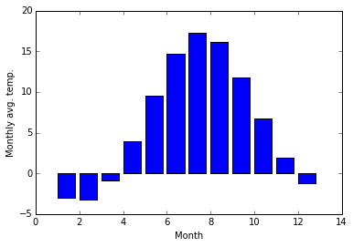

```python
months = arange(1,13)
monthly_mean = [mean(data[data[:,1] == month, 3]) for month in months]

fig, ax = subplots()
ax.bar(months, monthly_mean)
ax.set_xlabel("Month")
ax.set_ylabel("Monthly avg. temp.");
```

## Reshaping, resizing and stacking arrays

The shape of an Numpy array can be modified without copying the underlaying data, which makes it a fast operation even for large arrays.

```python
A
```

```
array([[ 0,  1,  2,  3,  4],
       [10, 11, 12, 13, 14],
       [20, 21, 22, 23, 24],
       [30, 31, 32, 33, 34],
       [40, 41, 42, 43, 44]])
```

```python
n, m = A.shape
```

```python
B = A.reshape((1,n*m))
B
```

```
array([[ 0,  1,  2,  3,  4, 10, 11, 12, 13, 14, 20, 21, 22, 23, 24, 30, 31,
        32, 33, 34, 40, 41, 42, 43, 44]])
```

```python
B[0,0:5] = 5 # modify the array

B
```

```
array([[ 5,  5,  5,  5,  5, 10, 11, 12, 13, 14, 20, 21, 22, 23, 24, 30, 31,
        32, 33, 34, 40, 41, 42, 43, 44]])
```

```python
A # and the original variable is also changed. B is only a different view of the same data
```

```
array([[ 5,  5,  5,  5,  5],
       [10, 11, 12, 13, 14],
       [20, 21, 22, 23, 24],
       [30, 31, 32, 33, 34],
       [40, 41, 42, 43, 44]])
```

We can also use the function `flatten` to make a higher-dimensional array into a vector. But this function create a copy of the data.

```python
B = A.flatten()

B
```

```
array([ 5,  5,  5,  5,  5, 10, 11, 12, 13, 14, 20, 21, 22, 23, 24, 30, 31,
       32, 33, 34, 40, 41, 42, 43, 44])
```

```python
B[0:5] = 10

B
```

```
array([10, 10, 10, 10, 10, 10, 11, 12, 13, 14, 20, 21, 22, 23, 24, 30, 31,
       32, 33, 34, 40, 41, 42, 43, 44])
```

```python
A # now A has not changed, because B's data is a copy of A's, not referring to the same data
```

```
array([[ 5,  5,  5,  5,  5],
       [10, 11, 12, 13, 14],
       [20, 21, 22, 23, 24],
       [30, 31, 32, 33, 34],
       [40, 41, 42, 43, 44]])
```

## Adding a new dimension: newaxis

With `newaxis`, we can insert new dimensions in an array, for example converting a vector to a column or row matrix:

```python
v = array([1,2,3])
```

```python
shape(v)
```

```
(3,)
```

```python
# make a column matrix of the vector v
v[:, newaxis]
```

```
array([[1],
       [2],
       [3]])
```

```python
# column matrix
v[:,newaxis].shape
```

```
(3, 1)
```

```python
# row matrix
v[newaxis,:].shape
```

```
(1, 3)
```

## Stacking and repeating arrays

Using function `repeat`, `tile`, `vstack`, `hstack`, and `concatenate` we can create larger vectors and matrices from smaller ones:

### tile and repeat

```python
a = array([[1, 2], [3, 4]])
```

```python
# repeat each element 3 times
repeat(a, 3)
```

```
array([1, 1, 1, 2, 2, 2, 3, 3, 3, 4, 4, 4])
```

```python
# tile the matrix 3 times
tile(a, 3)
```

```
array([[1, 2, 1, 2, 1, 2],
       [3, 4, 3, 4, 3, 4]])
```

### concatenate

```python
b = array([[5, 6]])
```

```python
concatenate((a, b), axis=0)
```

```
array([[1, 2],
       [3, 4],
       [5, 6]])
```

```python
concatenate((a, b.T), axis=1)
```

```
array([[1, 2, 5],
       [3, 4, 6]])
```

### hstack and vstack

```python
vstack((a,b))
```

```
array([[1, 2],
       [3, 4],
       [5, 6]])
```

```python
hstack((a,b.T))
```

```
array([[1, 2, 5],
       [3, 4, 6]])
```

## Copy and "deep copy"

To achieve high performance, assignments in Python usually do not copy the underlaying objects. This is important for example when objects are passed between functions, to avoid an excessive amount of memory copying when it is not necessary (technical term: pass by reference).

```python
A = array([[1, 2], [3, 4]])

A
```

```
array([[1, 2],
       [3, 4]])
```

```python
# now B is referring to the same array data as A
B = A
```

```python
# changing B affects A
B[0,0] = 10

B
```

```
array([[10,  2],
       [ 3,  4]])
```

```python
A
```

```
array([[10,  2],
       [ 3,  4]])
```

If we want to avoid this behavior, so that when we get a new completely independent object `B` copied from `A`, then we need to do a so-called "deep copy" using the function `copy`:

```python
B = copy(A)
```

```python
# now, if we modify B, A is not affected
B[0,0] = -5

B
```

```
array([[-5,  2],
       [ 3,  4]])
```

```python
A
```

```
array([[10,  2],
       [ 3,  4]])
```

## Iterating over array elements

Generally, we want to avoid iterating over the elements of arrays whenever we can (at all costs). The reason is that in a interpreted language like Python (or MATLAB), iterations are really slow compared to vectorized operations.

However, sometimes iterations are unavoidable. For such cases, the Python `for` loop is the most convenient way to iterate over an array:

```python
v = array([1,2,3,4])

for element in v:
    print(element)
```

```
1
2
3
4
```

```python
M = array([[1,2], [3,4]])

for row in M:
    print("row", row)

    for element in row:
        print(element)
```

```
('row', array([1, 2]))
1
2
('row', array([3, 4]))
3
4
```

When we need to iterate over each element of an array and modify its elements, it is convenient to use the `enumerate` function to obtain both the element and its index in the `for` loop:

```python
for row_idx, row in enumerate(M):
    print("row_idx", row_idx, "row", row)

    for col_idx, element in enumerate(row):
        print("col_idx", col_idx, "element", element)

        # update the matrix M: square each element
        M[row_idx, col_idx] = element ** 2
```

```
('row_idx', 0, 'row', array([1, 2]))
('col_idx', 0, 'element', 1)
('col_idx', 1, 'element', 2)
('row_idx', 1, 'row', array([3, 4]))
('col_idx', 0, 'element', 3)
('col_idx', 1, 'element', 4)
```

```python
# each element in M is now squared
M
```

```
array([[ 1,  4],
       [ 9, 16]])
```

## Performance

```python
%%timeit
M = array([[1,2], [3,4]])
for row_idx, row in enumerate(M):
    for col_idx, element in enumerate(row):
        # update the matrix M: square each element
        M[row_idx, col_idx] = element ** 2
```

```
100000 loops, best of 3: 6.16 µs per loop
```

```python
M = array([[1,2], [3,4]])
%timeit M*M
```

```
1000000 loops, best of 3: 453 ns per loop
```

```python
M
```

```
array([[1, 2],
       [3, 4]])
```

## Using arrays in conditions

When using arrays in conditions in for example `if` statements and other boolean expressions, one need to use one of `any` or `all`, which requires that any or all elements in the array evaluates to `True`:

```python
M
```

```
array([[1, 2],
       [3, 4]])
```

```python
if (M > 5).any():
    print("at least one element in M is larger than 5")
else:
    print("no element in M is larger than 5")
```

```
no element in M is larger than 5
```

```python
if (M > 5).all():
    print("all elements in M are larger than 5")
else:
    print("all elements in M are not larger than 5")
```

```
all elements in M are not larger than 5
```

## Further reading

- http://numpy.scipy.org
- http://scipy.org/Tentative_NumPy_Tutorial
- http://scipy.org/NumPy_for_Matlab_Users - A Numpy guide for MATLAB users.

# matplotlib - 2D and 3D plotting in Python

```python
# This line configures matplotlib to show figures embedded in the notebook,
# instead of opening a new window for each figure. More about that later.
# If you are using an old version of IPython, try using '%pylab inline' instead.
%matplotlib inline
```

## Introduction

Matplotlib is an excellent 2D and 3D graphics library for generating scientific figures. Some of the many advantages of this library include:

- Easy to get started
- Support for $\LaTeX$ formatted labels and texts
- Great control of every element in a figure, including figure size and DPI.
- High-quality output in many formats, including PNG, PDF, SVG, EPS, and PGF.
- GUI for interactively exploring figures *and* support for headless generation of figure files (useful for batch jobs).

One of the of the key features of matplotlib that I would like to emphasize, and that I think makes matplotlib highly suitable for generating figures for scientific publications is that all aspects of the figure can be controlled *programmatically*. This is important for reproducibility and convenient when one needs to regenerate the figure with updated data or change its appearance.

More information at the Matplotlib web page: http://matplotlib.org/

To get started using Matplotlib in a Python program, either include the symbols from the `pylab` module (the easy way):

```python
from pylab import *
```

or import the `matplotlib.pyplot` module under the name `plt` (the tidy way, **recommended**):

```python
import matplotlib.pyplot as plt
```

## MATLAB-like API

The easiest way to get started with plotting using matplotlib is often to use the MATLAB-like API provided by matplotlib.

It is designed to be compatible with MATLAB's plotting functions, so it is easy to get started with if you are familiar with MATLAB.

To use this API from matplotlib, we need to include the symbols in the `pylab` module:

```python
from pylab import *
```

### Example

A simple figure with MATLAB-like plotting API:

```python
x = linspace(0, 5, 10)
y = x ** 2
```

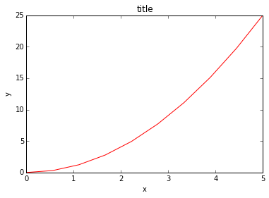

```python
figure()
plot(x, y, 'r')
xlabel('x')
ylabel('y')
title('title')
show()
```

Most of the plotting related functions in MATLAB are covered by the `pylab` module. For example, subplot and color/symbol selection:

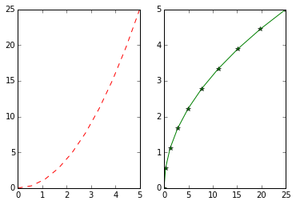

```python
subplot(1,2,1)
plot(x, y, 'r--')
subplot(1,2,2)
plot(y, x, 'g*-');
```

The good thing about the pylab MATLAB-style API is that it is easy to get started with if you are familiar with MATLAB, and it has a minimum of coding overhead for simple plots.

However, I'd encourage not using the MATLAB compatible API for anything but the simplest figures.

Instead, I recommend learning and using matplotlib's object-oriented plotting API. It is remarkably powerful. For advanced figures with subplots, insets and other components it is very nice to work with.

## The matplotlib object-oriented API

The main idea with object-oriented programming is to have objects that one can apply functions and actions on, and no object or program states should be global (such as the MATLAB-like API).

The real advantage of this approach becomes apparent when more than one figure is created, or when a figure contains more than one subplot.

To use the object-oriented API we start out very much like in the previous example, but instead of creating a new global figure instance we store a reference to the newly created figure instance in the `fig` variable, and from it we create a new axis instance `axes` using the `add_axes` method in the `Figure` class instance `fig`:

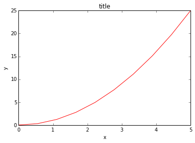

```python
fig = plt.figure()

axes = fig.add_axes([0.1, 0.1, 0.8, 0.8]) # left, bottom, width, height (range 0 to 1)

axes.plot(x, y, 'r')

axes.set_xlabel('x')
axes.set_ylabel('y')
axes.set_title('title');
```

Although a little bit more code is involved, the advantage is that we now have full control of where the plot axes are placed, and we can easily add more than one axis to the figure:

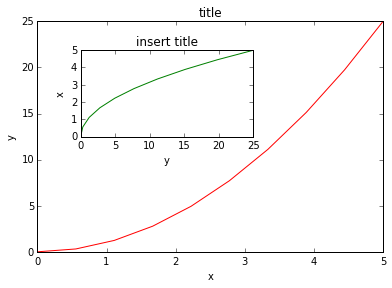

```python
fig = plt.figure()

axes1 = fig.add_axes([0.1, 0.1, 0.8, 0.8]) # main axes
axes2 = fig.add_axes([0.2, 0.5, 0.4, 0.3]) # inset axes

# main figure
axes1.plot(x, y, 'r')
axes1.set_xlabel('x')
axes1.set_ylabel('y')
axes1.set_title('title')

# insert
axes2.plot(y, x, 'g')
axes2.set_xlabel('y')
axes2.set_ylabel('x')
axes2.set_title('insert title');
```

If we don't care about being explicit about where our plot axes are placed in the figure canvas, then we can use one of the many axis layout managers in matplotlib.

A good one is `subplots`, which can be used like this:

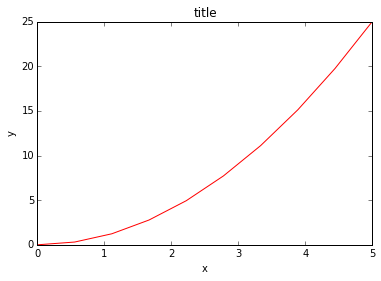

```python
fig, axes = plt.subplots()

axes.plot(x, y, 'r')
axes.set_xlabel('x')
axes.set_ylabel('y')
axes.set_title('title');
```

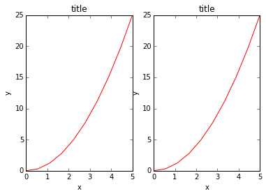

```python
fig, axes = plt.subplots(nrows=1, ncols=2)

for ax in axes:
    ax.plot(x, y, 'r')
    ax.set_xlabel('x')
    ax.set_ylabel('y')
    ax.set_title('title')
```

That was easy, but it isn't so pretty with overlapping figure axes and labels, right?

We can deal with that by using the `fig.tight_layout` method, which automatically adjusts the positions of the axes on the figure canvas so that there is no overlapping content:

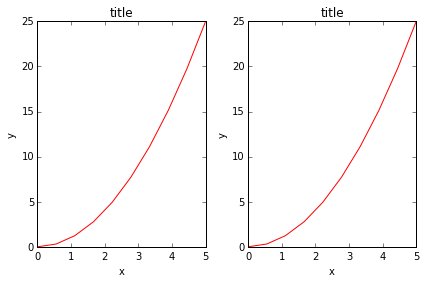

```python
fig, axes = plt.subplots(nrows=1, ncols=2)

for ax in axes:
    ax.plot(x, y, 'r')
    ax.set_xlabel('x')
    ax.set_ylabel('y')
    ax.set_title('title')

fig.tight_layout()
```

### Figure size, aspect ratio and DPI

Matplotlib allows the aspect ratio, DPI and figure size to be specified when the `Figure` object is created, using the `figsize` and `dpi` keyword arguments. `figsize` is a tuple of the width and height of the figure in inches, and `dpi` is the dots-per-inch (pixel per inch). To create an 800x400 pixel, 100 dots-per-inch figure, we can do:

```python
fig = plt.figure(figsize=(8,4), dpi=100)
```

The same arguments can also be passed to layout managers, such as the `subplots` function:

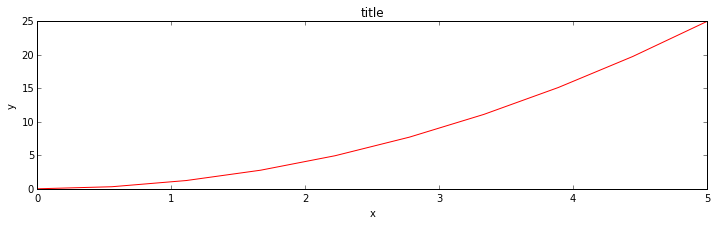

```python
fig, axes = plt.subplots(figsize=(12,3))

axes.plot(x, y, 'r')
axes.set_xlabel('x')
axes.set_ylabel('y')
axes.set_title('title');
```

### Saving figures

To save a figure to a file we can use the `savefig` method in the `Figure` class:

```python
fig.savefig("filename.png")
```

Here we can also optionally specify the DPI and choose between different output formats:

```python
fig.savefig("filename.png", dpi=200)
```

#### What formats are available and which ones should be used for best quality?

Matplotlib can generate high-quality output in a number formats, including PNG, JPG, EPS, SVG, PGF and PDF. For scientific papers, I recommend using PDF whenever possible. (LaTeX documents compiled with `pdflatex` can include PDFs using the `includegraphics` command). In some cases, PGF can also be good alternative.

### Legends, labels and titles

Now that we have covered the basics of how to create a figure canvas and add axes instances to the canvas, let's look at how decorate a figure with titles, axis labels, and legends.

**Figure titles**

A title can be added to each axis instance in a figure. To set the title, use the `set_title` method in the axes instance:

```python
ax.set_title("title");
```

**Axis labels**

Similarly, with the methods `set_xlabel` and `set_ylabel`, we can set the labels of the X and Y axes:

```python
ax.set_xlabel("x")
ax.set_ylabel("y");
```

**Legends**

Legends for curves in a figure can be added in two ways. One method is to use the `legend` method of the axis object and pass a list/tuple of legend texts for the previously defined curves:

```python
ax.legend(["curve1", "curve2", "curve3"]);
```

The method described above follows the MATLAB API. It is somewhat prone to errors and inflexible if curves are added to or removed from the figure (resulting in a wrongly labelled curve).

A better method is to use the `label="label text"` keyword argument when plots or other objects are added to the figure, and then using the `legend` method without arguments to add the legend to the figure:

```python
ax.plot(x, x**2, label="curve1")
ax.plot(x, x**3, label="curve2")
ax.legend();
```

The advantage with this method is that if curves are added or removed from the figure, the legend is automatically updated accordingly.

The `legend` function takes an optional keyword argument `loc` that can be used to specify where in the figure the legend is to be drawn. The allowed values of `loc` are numerical codes for the various places the legend can be drawn. See http://matplotlib.org/users/legend_guide.html#legend-location for details. Some of the most common `loc` values are:

```python
ax.legend(loc=0) # let matplotlib decide the optimal location
ax.legend(loc=1) # upper right corner
ax.legend(loc=2) # upper left corner
ax.legend(loc=3) # lower left corner
ax.legend(loc=4) # lower right corner
# .. many more options are available
```

The following figure shows how to use the figure title, axis labels and legends described above:

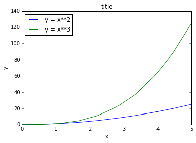

```python
fig, ax = plt.subplots()

ax.plot(x, x**2, label="y = x**2")
ax.plot(x, x**3, label="y = x**3")
ax.legend(loc=2); # upper left corner
ax.set_xlabel('x')
ax.set_ylabel('y')
ax.set_title('title');
```

### Formatting text: LaTeX, fontsize, font family

The figure above is functional, but it does not (yet) satisfy the criteria for a figure used in a publication. First and foremost, we need to have LaTeX formatted text, and second, we need to be able to adjust the font size to appear right in a publication.

Matplotlib has great support for LaTeX. All we need to do is to use dollar signs encapsulate LaTeX in any text (legend, title, label, etc.). For example, `"$y=x^3$"`.

But here we can run into a slightly subtle problem with LaTeX code and Python text strings. In LaTeX, we frequently use the backslash in commands, for example `\alpha` to produce the symbol $\alpha$. But the backslash already has a meaning in Python strings (the escape code character). To avoid Python messing up our latex code, we need to use "raw" text strings. Raw text strings are prepended with an '`r`', like `r"\alpha"` or `r'\alpha'` instead of `"\alpha"` or `'\alpha'`:

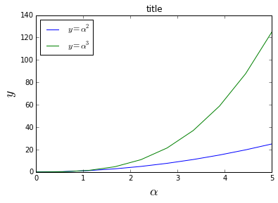

```python
fig, ax = plt.subplots()

ax.plot(x, x**2, label=r"$y = \alpha^2$")
ax.plot(x, x**3, label=r"$y = \alpha^3$")
ax.legend(loc=2) # upper left corner
ax.set_xlabel(r'$\alpha$', fontsize=18)
ax.set_ylabel(r'$y$', fontsize=18)
ax.set_title('title');
```

We can also change the global font size and font family, which applies to all text elements in a figure (tick labels, axis labels and titles, legends, etc.):

```python
# Update the matplotlib configuration parameters:
matplotlib.rcParams.update({'font.size': 18, 'font.family': 'serif'})
```

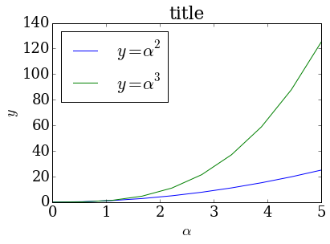

```python
fig, ax = plt.subplots()

ax.plot(x, x**2, label=r"$y = \alpha^2$")
ax.plot(x, x**3, label=r"$y = \alpha^3$")
ax.legend(loc=2) # upper left corner
ax.set_xlabel(r'$\alpha$')
ax.set_ylabel(r'$y$')
ax.set_title('title');
```

A good choice of global fonts are the STIX fonts:

```python
# Update the matplotlib configuration parameters:
matplotlib.rcParams.update({'font.size': 18, 'font.family': 'STIXGeneral', 'mathtext.fontset': 'stix'})
```

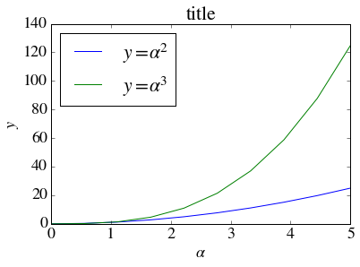

```python
fig, ax = plt.subplots()

ax.plot(x, x**2, label=r"$y = \alpha^2$")
ax.plot(x, x**3, label=r"$y = \alpha^3$")
ax.legend(loc=2) # upper left corner
ax.set_xlabel(r'$\alpha$')
ax.set_ylabel(r'$y$')
ax.set_title('title');
```

Or, alternatively, we can request that matplotlib uses LaTeX to render the text elements in the figure:

```python
matplotlib.rcParams.update({'font.size': 18, 'text.usetex': True})
```

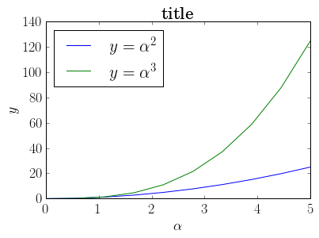

```python
fig, ax = plt.subplots()

ax.plot(x, x**2, label=r"$y = \alpha^2$")
ax.plot(x, x**3, label=r"$y = \alpha^3$")
ax.legend(loc=2) # upper left corner
ax.set_xlabel(r'$\alpha$')
ax.set_ylabel(r'$y$')
ax.set_title('title');
```

```python
# restore
matplotlib.rcParams.update({'font.size': 12, 'font.family': 'sans', 'text.usetex': False})
```

### Setting colors, linewidths, linetypes

#### Colors

With matplotlib, we can define the colors of lines and other graphical elements in a number of ways. First of all, we can use the MATLAB-like syntax where `'b'` means blue, `'g'` means green, etc. The MATLAB API for selecting line styles are also supported: where, for example, 'b.-' means a blue line with dots:

```python
# MATLAB style line color and style
ax.plot(x, x**2, 'b.-') # blue line with dots
ax.plot(x, x**3, 'g--') # green dashed line
```

We can also define colors by their names or RGB hex codes and optionally provide an alpha value using the `color` and `alpha` keyword arguments:

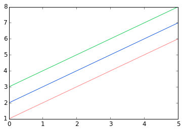

```python
fig, ax = plt.subplots()

ax.plot(x, x+1, color="red", alpha=0.5) # half-transparant red
ax.plot(x, x+2, color="#1155dd")        # RGB hex code for a bluish color
ax.plot(x, x+3, color="#15cc55")        # RGB hex code for a greenish color
```

#### Line and marker styles

To change the line width, we can use the `linewidth` or `lw` keyword argument. The line style can be selected using the `linestyle` or `ls` keyword arguments:

```python
def markerdemo():
    fig, ax = plt.subplots(figsize=(12,6))

    ax.plot(x, x+1, color="blue", linewidth=0.25)
    ax.plot(x, x+2, color="blue", linewidth=0.50)
    ax.plot(x, x+3, color="blue", linewidth=1.00)
    ax.plot(x, x+4, color="blue", linewidth=2.00)

    # possible linestype options ‘-‘, ‘–’, ‘-.’, ‘:’, ‘steps’
    ax.plot(x, x+5, color="red", lw=2, linestyle='-')
    ax.plot(x, x+6, color="red", lw=2, ls='-.')
    ax.plot(x, x+7, color="red", lw=2, ls=':')

    # custom dash
    line, = ax.plot(x, x+8, color="black", lw=1.50)
    line.set_dashes([5, 10, 15, 10]) # format: line length, space length, ...

    # possible marker symbols: marker = '+', 'o', '*', 's', ',', '.', '1', '2', '3', '4', ...
    ax.plot(x, x+ 9, color="green", lw=2, ls='*', marker='+')
    ax.plot(x, x+10, color="green", lw=2, ls='*', marker='o')
    ax.plot(x, x+11, color="green", lw=2, ls='*', marker='s')
    ax.plot(x, x+12, color="green", lw=2, ls='*', marker='1')

    # marker size and color
    ax.plot(x, x+13, color="purple", lw=1, ls='-', marker='o', markersize=2)
    ax.plot(x, x+14, color="purple", lw=1, ls='-', marker='o', markersize=4)
    ax.plot(x, x+15, color="purple", lw=1, ls='-', marker='o', markersize=8, markerfacecolor="red")
    ax.plot(x, x+16, color="purple", lw=1, ls='-', marker='s', markersize=8,
        markerfacecolor="yellow", markeredgewidth=2, markeredgecolor="blue");
```

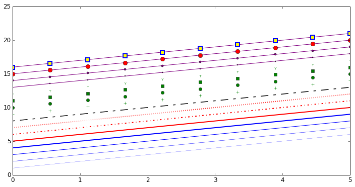

```python
markerdemo()
```

#### Logarithmic scale

It is also possible to set a logarithmic scale for one or both axes. This functionality is in fact only one application of a more general transformation system in Matplotlib. Each of the axes' scales are set separately using `set_xscale` and `set_yscale` methods which accept one parameter (with the value "log" in this case):

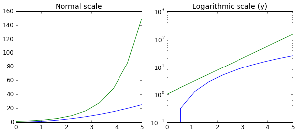

```python
fig, axes = plt.subplots(1, 2, figsize=(10,4))

axes[0].plot(x, x**2, x, exp(x))
axes[0].set_title("Normal scale")

axes[1].plot(x, x**2, x, exp(x))
axes[1].set_yscale("log")
axes[1].set_title("Logarithmic scale (y)");
```

#### Scientific notation

With large numbers on axes, it is often better use scientific notation:

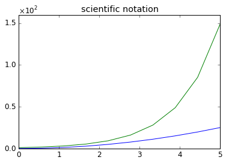

```python
fig, ax = plt.subplots(1, 1)

ax.plot(x, x**2, x, exp(x))
ax.set_title("scientific notation")

ax.set_yticks([0, 50, 100, 150])

from matplotlib import ticker
formatter = ticker.ScalarFormatter(useMathText=True)
formatter.set_scientific(True)
formatter.set_powerlimits((-1,1))
ax.yaxis.set_major_formatter(formatter)
```

### Axis number and axis label spacing

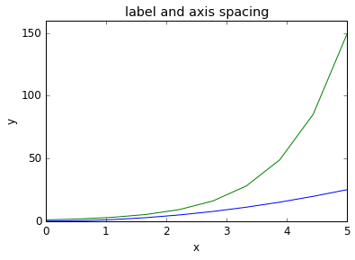

```python
# distance between x and y axis and the numbers on the axes
rcParams['xtick.major.pad'] = 5
rcParams['ytick.major.pad'] = 5

fig, ax = plt.subplots(1, 1)

ax.plot(x, x**2, x, exp(x))
ax.set_yticks([0, 50, 100, 150])

ax.set_title("label and axis spacing")

# padding between axis label and axis numbers
ax.xaxis.labelpad = 5
ax.yaxis.labelpad = 5

ax.set_xlabel("x")
ax.set_ylabel("y");
```

```python
# restore defaults
rcParams['xtick.major.pad'] = 3
rcParams['ytick.major.pad'] = 3
```

#### Axis position adjustments

Unfortunately, when saving figures the labels are sometimes clipped, and it can be necessary to adjust the positions of axes a little bit. This can be done using `subplots_adjust`:

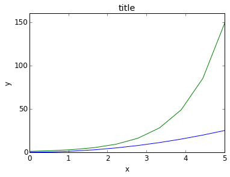

```python
fig, ax = plt.subplots(1, 1)

ax.plot(x, x**2, x, exp(x))
ax.set_yticks([0, 50, 100, 150])

ax.set_title("title")
ax.set_xlabel("x")
ax.set_ylabel("y")

fig.subplots_adjust(left=0.15, right=.9, bottom=0.1, top=0.9);
```

### Axis grid

With the `grid` method in the axis object, we can turn on and off grid lines. We can also customize the appearance of the grid lines using the same keyword arguments as the `plot` function:

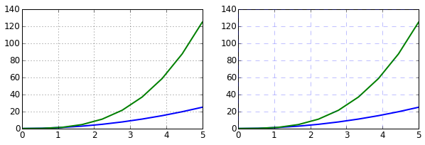

```python
fig, axes = plt.subplots(1, 2, figsize=(10,3))

# default grid appearance
axes[0].plot(x, x**2, x, x**3, lw=2)
axes[0].grid(True)

# custom grid appearance
axes[1].plot(x, x**2, x, x**3, lw=2)
axes[1].grid(color='b', alpha=0.5, linestyle='dashed', linewidth=0.5)
```

### Other 2D plot styles

In addition to the regular `plot` method, there are a number of other functions for generating different kind of plots. See the matplotlib plot gallery for a complete list of available plot types: http://matplotlib.org/gallery.html. Some of the more useful ones are show below:

```python
n = array([0,1,2,3,4,5])
xx = np.linspace(-0.75, 1., 100)
```

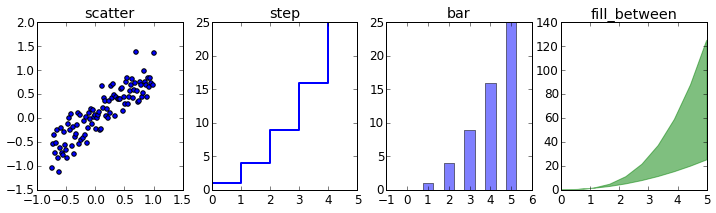

```python
fig, axes = plt.subplots(1, 4, figsize=(12,3))

axes[0].scatter(xx, xx + 0.25*randn(len(xx)))
axes[0].set_title("scatter")

axes[1].step(n, n**2, lw=2)
axes[1].set_title("step")

axes[2].bar(n, n**2, align="center", width=0.5, alpha=0.5)
axes[2].set_title("bar")

axes[3].fill_between(x, x**2, x**3, color="green", alpha=0.5);
axes[3].set_title("fill_between");
```

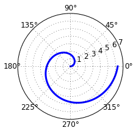

```python
# polar plot using add_axes and polar projection
fig = plt.figure()
ax = fig.add_axes([0.0, 0.0, .6, .6], polar=True)
t = linspace(0, 2 * pi, 100)
ax.plot(t, t, color='blue', lw=3);
```

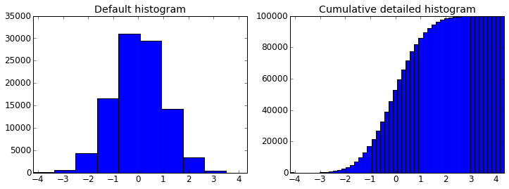

```python
# A histogram
n = np.random.randn(100000)
fig, axes = plt.subplots(1, 2, figsize=(12,4))

axes[0].hist(n)
axes[0].set_title("Default histogram")
axes[0].set_xlim((min(n), max(n)))

axes[1].hist(n, cumulative=True, bins=50)
axes[1].set_title("Cumulative detailed histogram")
axes[1].set_xlim((min(n), max(n)));
```

### Text annotation

Annotating text in matplotlib figures can be done using the `text` function. It supports LaTeX formatting just like axis label texts and titles:

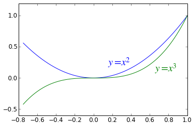

```python
fig, ax = plt.subplots()

ax.plot(xx, xx**2, xx, xx**3)

ax.text(0.15, 0.2, r"$y=x^2$", fontsize=20, color="blue")
ax.text(0.65, 0.1, r"$y=x^3$", fontsize=20, color="green");
```

### Figures with multiple subplots and insets

Axes can be added to a matplotlib Figure canvas manually using `fig.add_axes` or using a sub-figure layout manager such as `subplots`, `subplot2grid`, or `gridspec`:

#### subplots

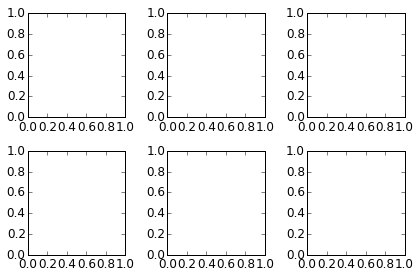

```python
fig, ax = plt.subplots(2, 3)
fig.tight_layout()
```

#### subplot2grid

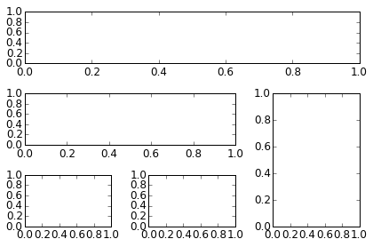

```python
fig = plt.figure()
ax1 = plt.subplot2grid((3,3), (0,0), colspan=3)
ax2 = plt.subplot2grid((3,3), (1,0), colspan=2)
ax3 = plt.subplot2grid((3,3), (1,2), rowspan=2)
ax4 = plt.subplot2grid((3,3), (2,0))
ax5 = plt.subplot2grid((3,3), (2,1))
fig.tight_layout()
```

### Colormap and contour figures

Colormaps and contour figures are useful for plotting functions of two variables. In most of these functions we will use a colormap to encode one dimension of the data. There are a number of predefined colormaps. It is relatively straightforward to define custom colormaps. For a list of pre-defined colormaps, see: http://www.scipy.org/Cookbook/Matplotlib/Show_colormaps

```python
alpha = 0.7
phi_ext = 2 * pi * 0.5

def flux_qubit_potential(phi_m, phi_p):
    return 2 + alpha - 2 * cos(phi_p)*cos(phi_m) - alpha * cos(phi_ext - 2*phi_p)
```

```python
phi_m = linspace(0, 2*pi, 100)
phi_p = linspace(0, 2*pi, 100)
X,Y = meshgrid(phi_p, phi_m)
Z = flux_qubit_potential(X, Y).T
```

#### imshow

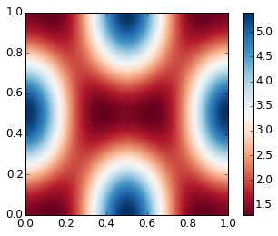

```python
fig, ax = plt.subplots()

im = ax.imshow(Z, cmap=cm.RdBu, vmin=abs(Z).min(), vmax=abs(Z).max(), extent=[0, 1, 0, 1])
im.set_interpolation('bilinear')

cb = fig.colorbar(im, ax=ax)
```

#### contour

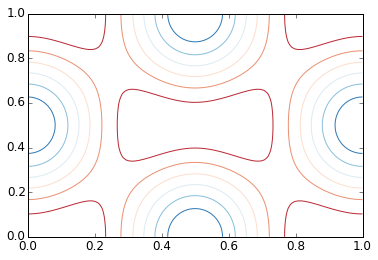

```python
fig, ax = plt.subplots()

cnt = ax.contour(Z, cmap=cm.RdBu, vmin=abs(Z).min(), vmax=abs(Z).max(), extent=[0, 1, 0, 1])
```

## Further reading

- http://www.matplotlib.org - The project web page for matplotlib.
- https://github.com/matplotlib/matplotlib - The source code for matplotlib.
- http://matplotlib.org/gallery.html - A large gallery showcasing various types of plots matplotlib can create. Highly recommended!
- http://www.loria.fr/~rougier/teaching/matplotlib - A good matplotlib tutorial.
- http://scipy-lectures.github.io/matplotlib/matplotlib.html - Another good matplotlib reference.

# Until next time...

## To get the necessary software (and some practice)

1. Install the Anaconda Python Distribution
2. Get a GitHub account and the Student Developer Pack
3. Download this IPython notebook from theclass github repository ([https://github.com/mjuric/ast597b])
4. Open the notebook and evaluate all cells

## Extra credit

1. Fork and then clone to your own computer the github repository of ASTR 597b
2. Correct and then commit any mistakes you find in this notebook (typos included :) )
3. Send me a pull request!